# The NBA and R

Ben Goldin

## An Introduction to R Through a 3-pointer

While many associate sports data science with Moneyball and remember it as a fad of the early 2000s, sports like basketball are seemingly being dominated by those buying into sports analytics. Of course this comes with heaps of debate, and most in the field itself would agree there is no one metric to completely understand the game with, but at the very least they give teams new perspectives on how to improve. Daryl Morey, the general manager of the Houston Rockets, and Mike Zarren, assistant GM of the Boston Celtics, are influential figures within the field of data science and can be seen as some of the biggest reasons for their teams’ successes. Since we want to both introduce the R language and data science, let’s begin with a simple look into the 3-pointer.

## A Game of “Buckets”

Basketball is a game of making shots, with free throws counting as 1-pointers, normal field goals counting as 2-pointers, and 3-point field goals counting as 3-pointers. What distinguishes a 3-point field goal is their distance to the hoop ranging from 22 feet near the corners of the court to 23.75 feet near the center of the court. Going forward I’ll be referring to 3-point attempts as 3PA, made 3-pointers as 3P, 2-point attempts as 2PA, made 2-pointers as 2P, field goal attempts (which include both 2 and 3-pointers) as FGA, and made field goals as FG.

Diving right in, let’s look at some 3-point statistics to get a better sense of their value across the league:

## Welcome to R

```r
#Loading Data
data<-read.csv("SeasonsData.csv")
data<-as.data.frame(data)
#Column names of our data
colnames(data)
```

```
##  [1] "Rk"     "Season" "Lg"     "Age"    "Ht"     "Wt"     "G"
##  [8] "MP"     "FG"     "FGA"    "X3P"    "X3PA"   "FT"     "FTA"
## [15] "ORB"    "DRB"    "TRB"    "AST"    "STL"    "BLK"    "TOV"
## [22] "PF"     "PTS"    "FG."    "X3P."   "FT."    "Pace"   "eFG."
## [29] "TOV."   "ORB."   "FT.FGA" "ORtg"
```

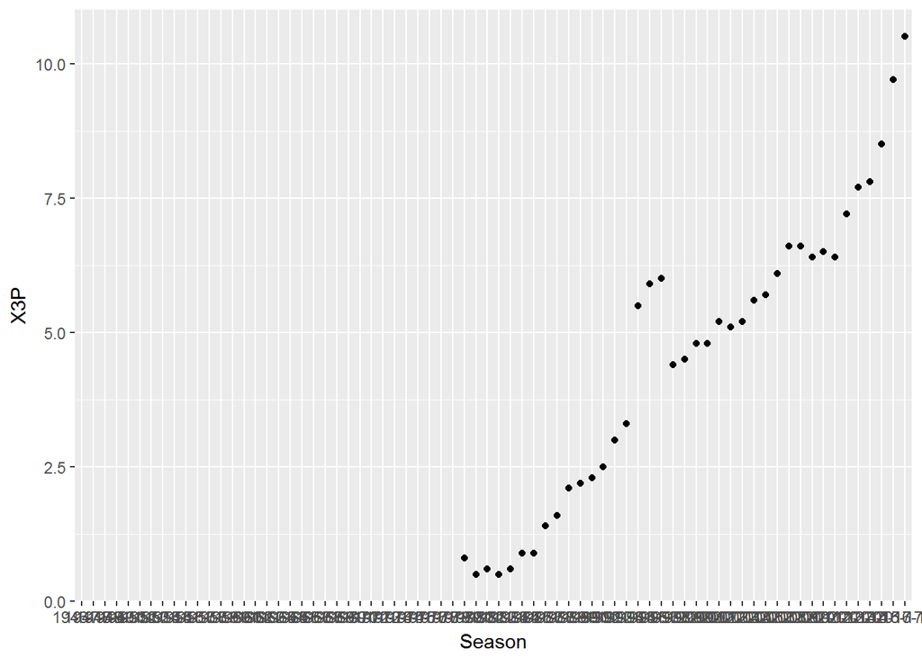

```r
#Selecting Seasons and 3-Pointers Made Per Season
threes<-select(data,Season,X3P)

#Basic Graphing
ggplot(threes,
  aes(x=Season, y=X3P)) +
  geom_point()
```

So that’s a…“nice” start, but atleast we can gather that in general 3 pointers are getting more popular. However, we can do better with our data and the way we’re presenting it. While it’s interesting to learn that 3 pointers only came into existence in the 1980 season, we don’t need to be reminded of that every single time by giving up half of our graph space. Let’s remove any years with an NA in the 3 point column.

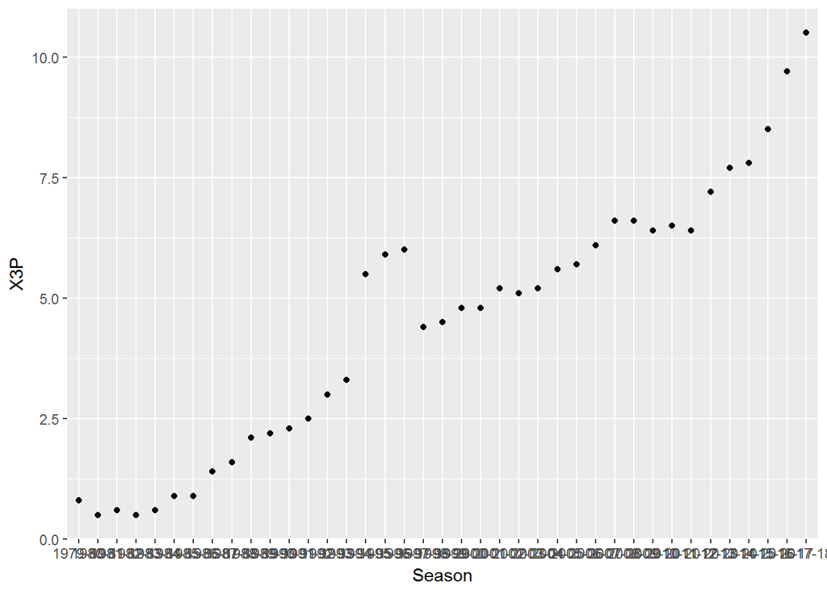

```r
#Removing Irrelevant Seasons
threes<-na.omit(threes)
ggplot(threes,
  aes(x=Season, y=X3P)) +
  geom_point()
```

Furthermore, let’s clean up our graph and make it a little bit more readable.

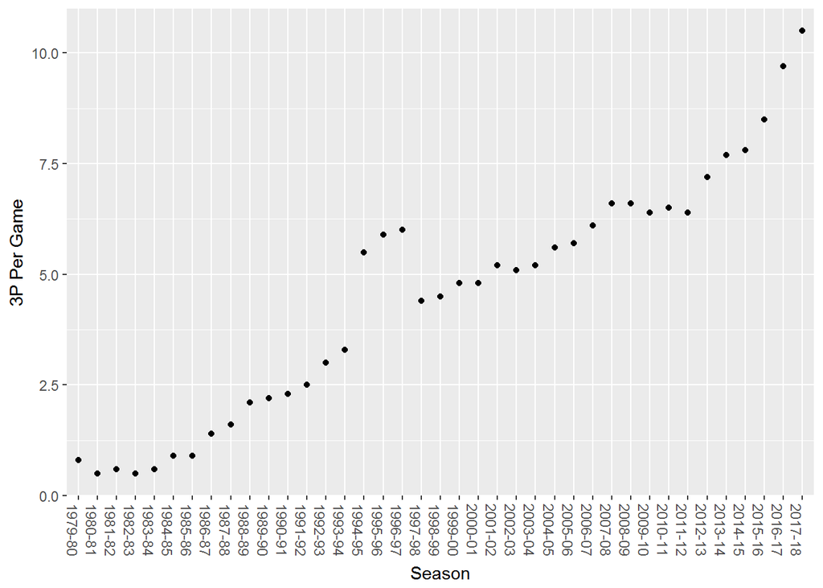

```r
#Changing factors to characters
threes %>%
  mutate_if(is.factor, as.character) -> threes

ggplot(threes,
  aes(x=Season, y=X3P)) +
  geom_point() +
  ylab("3P Per Game") +
  theme(axis.text.x = element_text(angle = 270))
```

So 3-pointers are getting more popular, but in general do teams that make 3-pointers win more? Instead of plotting across time, let’s plot across team wins. While we have all the tables locally, to spice things up let’s also do a quick HTML scrape to look at another way R can easily compile data from the web when needed.

```r
#We read the HTML of the desired URL looking for a "table" that we then convert using html_table.
url <- "https://www.basketball-reference.com/pi/shareit/XXXE0"
  html <- xml2::read_html(url)
  node <- rvest::html_node(html, "table")
  table <- rvest::html_table(node, header = TRUE)
Team3<-select(table,Team,"3P")
```

And we can load the rest of the data for the teams into a second table.

```r
#Loading Data
data2<-read.csv("WinData.csv")
data2<-as.data.frame(data2)

#Selecting Team Names and Wins
wins<-select(data2,Team,W)
```

With two tables now, both sharing team names, one has 3-pointers made and the other has wins. Let’s create a larger table containing this combined information.

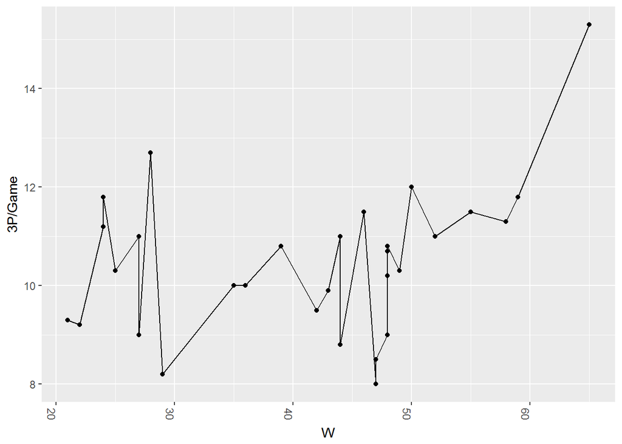

```r
combined<-merge(Team3,wins, by = "Team")
combined[, '3P'] <- as.numeric(combined[, '3P'])
colnames(combined)[2]<-"Three"
ggplot(combined,
  aes(x=W, y=Three)) +
  geom_point() +
  geom_line() +
  ylab("3P/Game") +
  theme(axis.text.x = element_text(angle = 270))
```

So there really isn’t that strong of a coorelation, however it was interesting to see nonetheless. Let’s get back to that point though about R’s scraping abilities. There are two metrics, offensive rating (ORtg) and defensive rating (DRtg) which again like any metric aren’t perfect, but can give some kind of look into how successful a team is on offense or defense. What we can look to do is look back in time and scrape the offensive and defensive rating for both teams’ histories and plot them over time, and, let’s also plot these 2 ratings side by side for each team.

```
## geom_path: Each group consists of only one observation. Do you need to
## adjust the group aesthetic?
## geom_path: Each group consists of only one observation. Do you need to
## adjust the group aesthetic?
```

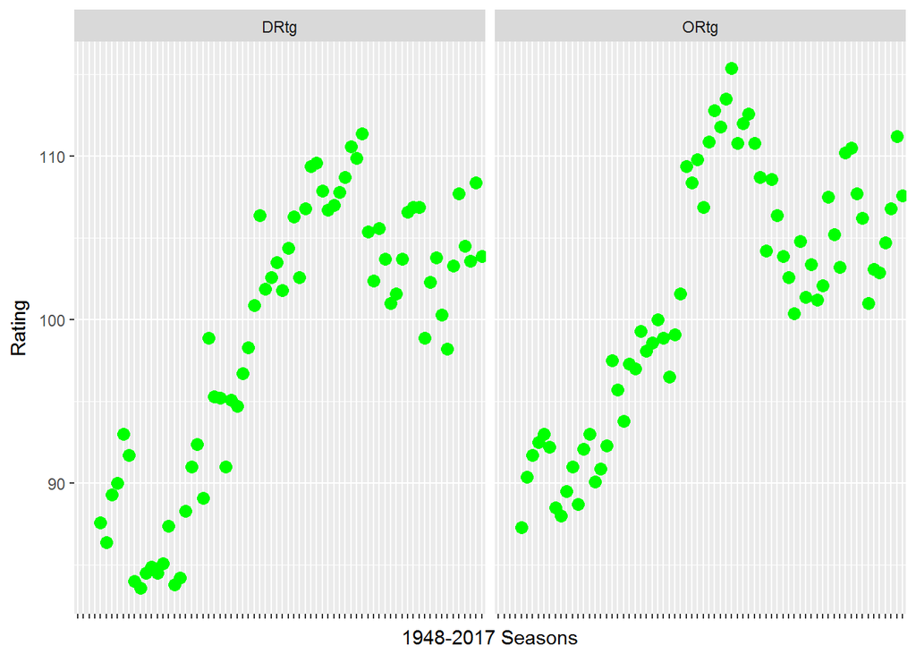

```r
urlc <- "https://www.basketball-reference.com/teams/BOS/"
  htmlc <- xml2::read_html(urlc)
  nodec <- rvest::html_node(htmlc, "table")
  tablec <- rvest::html_table(nodec, header = TRUE)

cstats<-select(tablec,Season,ORtg,DRtg)

cstats %>% tidyr::gather("id", "value", 2:3) %>%
  ggplot(., aes(Season, value))+
  geom_point(colour = "green", size = 3)+
  theme(axis.text.x=element_blank())+
  geom_line() +
  facet_wrap(~id) +
  xlab("1948-2017 Seasons") +
  ylab("Rating")
```

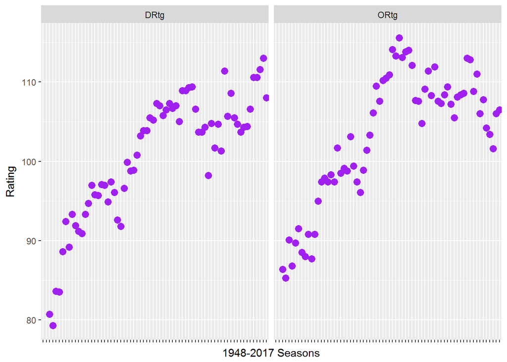

```r
urll <- "https://www.basketball-reference.com/teams/LAL/"
  htmll <- xml2::read_html(urll)
  nodel <- rvest::html_node(htmll, "table")
  tablel <- rvest::html_table(nodel, header = TRUE)

lstats<-select(tablel,Season,ORtg,DRtg)

lstats %>% tidyr::gather("id", "value", 2:3) %>%
  ggplot(., aes(Season, value))+
  geom_point(colour = "purple", size = 3)+
  theme(axis.text.x=element_blank())+
  geom_smooth(method = lm) +
  facet_wrap(~id) +
  xlab("1948-2017 Seasons") +
  ylab("Rating")
```

The pace and general state of the game can be seen with these graphs (a shift from defense to offense focused teams), but as expected, there is much more one can do. Overall, this tutorial wasn’t meant to be and end all anything, not a complete guide to data science, not a complete guide to R, and definetly not some hidden insight into some futuristic metrics to dominate basketball with (let’s be honest we looked at pretty basic stats). However, I hope you can take from it some interesting tidbits in any of those subject areas and run with it because the availability of data and processing power we have today is the best it has been and will only continue to grow!

Thanks for reading - Ben

P.S. For those interested in more R or NBA related content, might I suggest:

(For the data scraper in you)  
http://www.programmingr.com/examples/examples-web-scraping-r/  
https://www.analyticsvidhya.com/blog/2017/03/beginners-guide-on-web-scraping-in-r-using-rvest-with-hands-on-knowledge/

(For the data analyzers)  
http://trevorstephens.com/kaggle-titanic-tutorial/r-part-5-random-forests/  
http://personal.psu.edu/drh20/astrostatistics/PennState2010/test_est.html

(For the data visualizers)  
https://twitter.com/dsparks?lang=en  
https://twitter.com/kirkgoldsberry?lang=en

(For the sports data nerd)  
https://www.theringer.com/  
https://fivethirtyeight.com/sports/  
https://grantland.com/contributors/kirk-goldsberry/

(For the Hector lover)  
http://www.hcbravo.org/